# Parameter Optimization Report

Automated Report Generation for sbmlsim

Author

Generated by sbmlsim reporting module

Published

January 30, 2026

## Executive Summary

[output not shown]

**Model:** ecoli_core_model  
**Method:** Parameter Optimization - Levenberg-Marquardt  
**Software:** sbmlsim v0.2.2  
**Timestamp:** 2026-01-30T14:30:00

## Optimized Parameters

```
| Parameter    |   Estimate |   CI Lower |   CI Upper | Unit     |
|:-------------|-----------:|-----------:|-----------:|:---------|
| k_cat_PFK    |      0.512 |      0.489 |      0.535 | 1/s      |
| K_m_glucose  |      1.234 |      1.189 |      1.279 | mM       |
| V_max_GAPDH  |      3.456 |      3.298 |      3.614 | mmol/L/s |
| k_inhibition |      0.089 |      0.078 |      0.1   | 1/mM     |
```

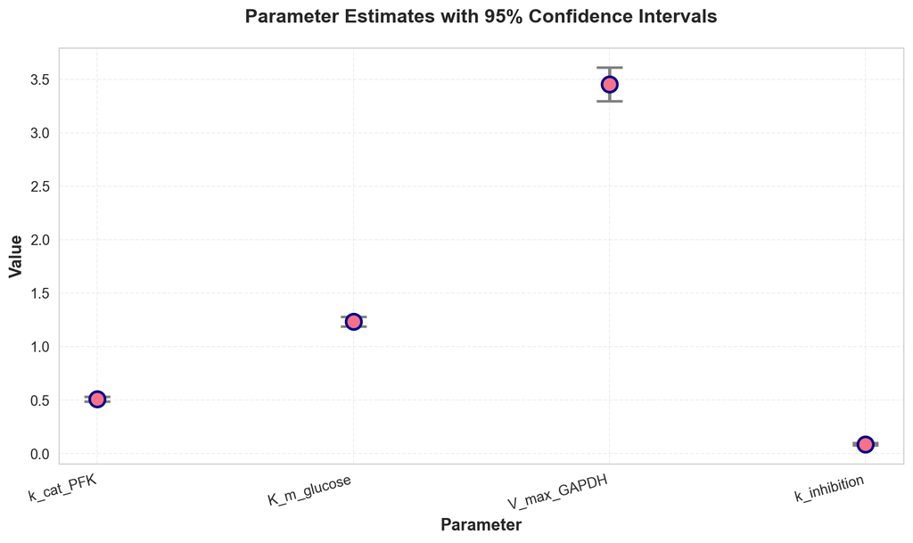

Parameter Estimates with 95% Confidence Intervals

## Goodness of Fit

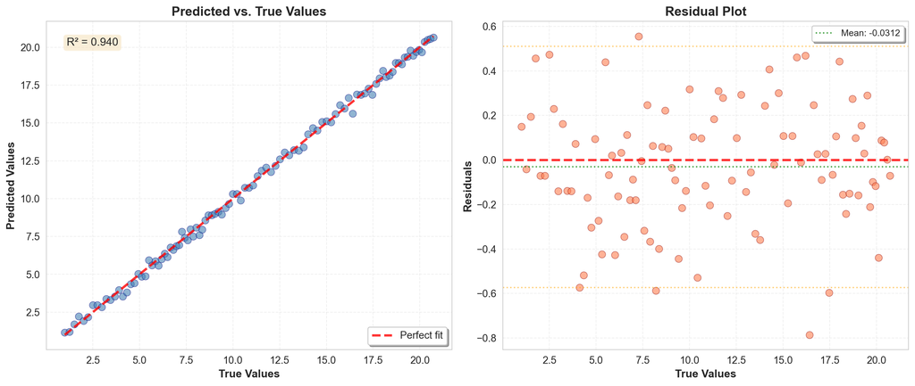

Model Predictions vs. True Values and Residual Analysis

## Model Performance

### Training vs. Validation

[figure not shown]

Training and Validation Performance Comparison

### Statistical Quality Metrics

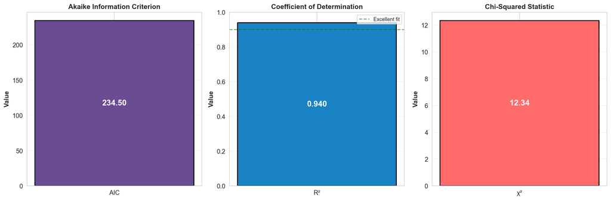

Distribution of Quality Metrics

## Methods & Settings

**Software:** sbmlsim v0.2.2  
**Optimization Method:** Levenberg-Marquardt  
**Objective Function:** Least Squares  
**Convergence Criterion:** Relative tolerance < 1e-06  
**Iterations to Convergence:** 42

**Data:**

- Training samples: 100
- Validation samples: 30
- Degrees of freedom: 96

**Model:** ecoli_core_model

## Reproducibility Information

This report was automatically generated using:

- **sbmlsim:** sbmlsim v0.2.2
- **Quarto:** v1.8+
- **Python:** 3.10+
- **Libraries:** pandas, numpy, matplotlib, seaborn

**Report generated:** 2026-01-30T14:30:00  
**Generated by:** atul_gsoc_demo

### To reproduce these results:

```bash
# Run parameter optimization
sbmlsim optimize model.xml --params config.json --output results/

# Generate report
sbmlsim report generate results/ --template parameter_optimization
```

### Integration with sbmlsim

This template demonstrates the proof-of-concept for Issue [#180](https://github.com/matthiaskoenig/sbmlsim/issues/180) and GSoC project [#281](https://github.com/nrnb/GoogleSummerOfCode/issues/281).

**Proposed API:**

```python
from sbmlsim.reporting import generate_quarto_report

# After optimization
results = optimizer.optimize(model, data)

# Generate interactive HTML report
generate_quarto_report(
    results,
    template='parameter_optimization',
    output='report.html',
    format='html'
)

# Generate static PDF report (via Typst)
generate_quarto_report(
    results,
    template='parameter_optimization',
    output='report.pdf',
    format='pdf'
)
```

## Next Steps

This prototype demonstrates the following capabilities for Issue #180:

**Future enhancements:**

- Add profile likelihood plots for parameter uncertainty
- Support sensitivity analysis results (heatmaps, summary tables)
- Create Typst templates for static PDF generation
- Add interactive plotly visualizations for web reports
- CI/CD integration for automated report generation
- GitHub Pages deployment workflow
- Support for SED-ML and PEtab workflows
- Literature review templates (PRISMA diagrams)